# Exploring the BRFSS data

## Setup

### Load packages

```r
library(ggplot2)
library(dplyr)
```

### Load data

firstly we load the dataset of the brfss2013 here

```r
load("brfss2013.RData")
```

## Part 1: Data

The data is health-related telephone surveys that collect state data about U.S. residents regarding their health-related risk behaviours, chronic health conditions, and use of preventive services. The Behavioural Risk Factor Surveillance System (BRFSS) conducted more than 400,000 adult interviews each year.

In a telephone survey such as the BRFSS, a sample record is one telephone number in the list of all telephone numbers the system randomly selects for dialing. To meet the BRFSS standard for the participating states’ sample designs, one must be able to justify sample records as a probability sample of all households with telephones in the state. All participating areas met this criterion in 2016.

Fifty-one projects used a disproportionate stratified sample (DSS) design for their landline samples. Guam, Puerto Rico, and the US Virgin Islands used a simple random-sample design.

The dataset is the random sampling, the research result is generalizable. There are no control groups were assigned to any group. Therefore, the research didn’t use random assignment.

The dataset contains 491,775 observations of 330 variables and more information can refer to https://www.cdc.gov/brfss/

## Part 2: Research questions

**Research question 1:**

HOW MUCH SLEEP DO WE REALLY NEED?  
Sleep is a important indicator of overall health and well-being. We spend up to one-third of our lives asleep, and the overall state of our “sleep health” remains an essential question throughout our lifespan. The sleep time could affect the health. Thus, The research question is the association between sleeping time and health situation. Inadequate sleep issue always is the modern people problem nowadays. The 3 variables (Sleep time, Mental health, and Physical health) to be used to plot the graph shows the association between sleep time and the mental health condition to find out if the sleep time can alter the mental health, and similarly the association between sleep time and physical health.

**Research question 2:**

Financial problems or financial pressure is a situation where money worries are causing you stress. Many people are facing hard financial times and the impact on mental health can be significant. These problems can seem impossible to overcome, but you can get help and take steps to improve your situation. The objective of my research is to find out the relationship between employment status and the income level affect people’s health. The 3 variables to be exploited (employment status, income level and general health) because the employment may be related with income level and these two variables should have shared effect on general health. In R analysis, we should be able to identify the consequence of both on general health and employment status may affect the relationship between the income level and general health.

**Research question 3:**

Smoking can cause cancer almost anywhere in human body such as Bladder, Blood (acute myeloid leukemia), Cervix, Colon and rectum (colorectal), Esophagus, Kidney and ureter, Larynx, Liver, Oropharynx (includes parts of the throat, tongue, soft palate, and the tonsils), Pancreas, Stomach, Trachea, bronchus, and lung. Smoking harms nearly every organ of the body and affects a person’s overall health.

The research question proposed if the frequency of smoking affect health condition and how it vary when smokes at a different level. The variable “smokeday2” (frequency of days now smoking) and “physhlth” (number of days physical health not good) and menthlth (number of days mental health not good) to measure their association. This study could help to detect if the more frequent people smoke the worse their health condition will be.

## Part 3: Exploratory data analysis

**Research question 1:**

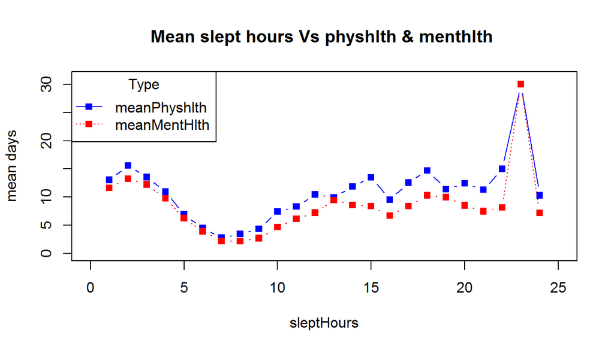

```r
meanPhysHlth <- c()
meanMentHlth <- c()
sleptHours <- 1:24
for(i in 1 :24){
  meanPhysHlth[i] <- mean(subset(brfss2013, brfss2013$sleptim1 == i)$physhlth, na.rm=TRUE)

  meanMentHlth[i] <- mean(subset(brfss2013, brfss2013$sleptim1 == i)$menthlth, na.rm=TRUE)
}
plot(sleptHours, meanPhysHlth, type="b",lty=1, xlim = c(0,25), ylim = c(0,31), col="blue",pch=15,ylab = "")
lines(sleptHours, meanMentHlth, type="b",lty=3, col="red",pch=15)

title("Mean slept hours Vs physhlth & menthlth ",ylab = "mean days")
legend("topleft", title = "Type",legend = c("meanPhyshlth", "meanMentHlth"), lty=c(1,3),pch=c(15,15),col = c("blue","red"))
```

```r
summary(sleptHours)
```

```
##    Min. 1st Qu.  Median    Mean 3rd Qu.    Max.
##    1.00    6.75   12.50   12.50   18.25   24.00
```

```r
summary(meanMentHlth)
```

```
##    Min. 1st Qu.  Median    Mean 3rd Qu.    Max.
##   2.206   6.255   8.312   8.577   9.829  30.000
```

```r
summary(meanPhysHlth)
```

```
##    Min. 1st Qu.  Median    Mean 3rd Qu.    Max.
##   2.804   8.107  11.154  11.011  13.171  30.000
```

**Research question 2:**

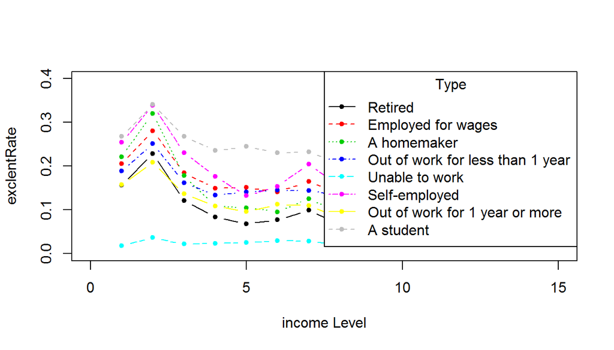

```r
firstFlag = TRUE
ltyNum <- 1
incomeLevel <- 1
emps = c()
for(emp in unique(brfss2013$employ1)){
  if(!is.na(emp)){
    emps[ltyNum] <- emp
    subbrf <- subset(brfss2013, brfss2013$employ1 == emp)
    exclentRate <- 1
    i <- 1
    for(incom in unique(brfss2013$income2)){
      if(!is.na(incom)){
        incomeLevel[i] <- incom
        secsubbrf <- subset(subbrf , subbrf$income2 == incom)
        exclentRate[i] <- unname(prop.table(table(secsubbrf$genhlth))[1])
        i <- i + 1
      }
    }
    incomeLevel[1:length(incomeLevel)] <- 1:length(incomeLevel)
    if(firstFlag){
      plot(incomeLevel, exclentRate,lty=ltyNum, pch = 20, type = "b", ylim = c(0,0.4), xlim = c(0,15),xlab = "income Level",col=ltyNum)
      firstFlag = FALSE
    }else{
      lines(incomeLevel, exclentRate, col=ltyNum,lty=ltyNum, pch = 20, type = "b")
    }
      ltyNum <- ltyNum + 1
  }
}
legend("topright", title = "Type",legend = emps, lty=1:ltyNum,pch=20,col = 1:ltyNum)
```

In research question no. 2 analysis, all employment status except unable to work, at first when income level goes up the general health condition becomes better but when the income level reaches value 2 general health condition falls when income continue increases. Usually, higher income may bring up higher work pressure and high work pressure might affect health condition.

The finding outcome is the employment status and income level could affect general health condition.

```r
summary(emp)
```

```
##    Length     Class      Mode
##         1 character character
```

```r
summary(exclentRate)
```

```
##    Min. 1st Qu.  Median    Mean 3rd Qu.    Max.
##  0.2047  0.2318  0.2403  0.2532  0.2682  0.3410
```

```r
summary(incomeLevel)
```

```
##    Length     Class      Mode
##         8 character character
```

**Research question 3:**

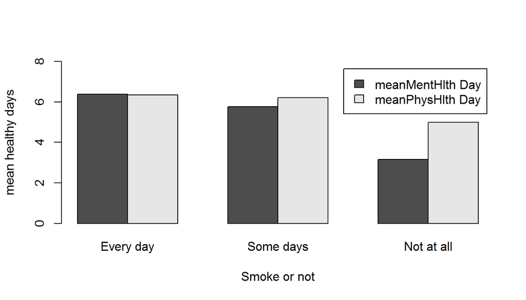

```r
meanMentHlth <- c()
meanPhysHlth <- c()
smokeLevels = levels(brfss2013$smokday2)
i <- 1
for(lev in smokeLevels){
  meanMentHlth[i] <- mean(subset(brfss2013, brfss2013$smokday2 == lev)$menthlth, na.rm=TRUE)
  meanPhysHlth[i] <- mean(subset(brfss2013, brfss2013$smokday2 == lev)$physhlth, na.rm=TRUE)
  i <- i + 1
}
resultMatrix <- matrix(append(meanMentHlth, meanPhysHlth), nrow = 3, dimnames = list(smokeLevels,c("meanMentHlth", "meanPhysHlth")))
resultMatrix <- t(resultMatrix)
barplot(resultMatrix, beside = TRUE, legend.text = c("meanMentHlth Day", "meanPhysHlth Day"),xlab = "Smoke or not", ylab = "mean healthy days",ylim = c(0,8))
```

In research question no. 3 analysis, the study about the effect smoking has on health condition.

In the bar chart shows that the frequency people smoke everyday affect both physical and mental health seriously. In theory and practical, the more frequent people smoke, the worse their physical and mental health will be.

If the people who smoke some days their mental and physical health are both affected. People who Not smoke at all, their physical health condition are worse than mental health condition.

The research finding outcome does smoking affects health condition.

```r
summary(meanPhysHlth)
```

```
##    Min. 1st Qu.  Median    Mean 3rd Qu.    Max.
##   4.986   5.595   6.205   5.844   6.274   6.343
```

```r
summary(meanMentHlth)
```

```
##    Min. 1st Qu.  Median    Mean 3rd Qu.    Max.
##   3.159   4.465   5.770   5.105   6.078   6.386
```

```r
summary(smokeLevels)
```

```
##    Length     Class      Mode
##         3 character character
```

Analysis by Swee Jer Wei